# 2018 MERL Tech DC workshop: Up your Data Game with R

This tutorial was developed for a workshop at MERL Tech DC in 2018 and presented with Jonathan Seiden. You can find the R code and slides on [Github](https://github.com/cguedenet/MERL-Tech-workshop.git).

R Studio is an “Integrated Development Environment”, or IDE. This means it is a front-end for R that makes it much easier to work with. R Studio is also free, and available for Windows, Mac, and Linux platforms.

# Cleaning your data

Analyzing survey data typically starts with cleaning, recoding, and restructuring, or even joining data sets. For example, you may want to know how many missing cases there are or how many people responded to each question. Or you may want to group certain continuous variables like ages or income into ranges. Lastly, you may want to find and deal with outliers.

Functions like distinct() cab quickly get rid of duplicate rows across all variables or for specific variables (e.g. a person’s ID or email address)

Functions like mutate() can help create new variables. For example, creating a new variable for age ranges based on an existing variable for age.

```r
# remove duplicated rows (if any). The distinct() function keeps only unique rows.
df <- distinct(df)

# You can also choose to remove duplicated rows for specific variables like ID.x and ID.y
df <- distinct(df, ID.x, ID.y, .keep_all = TRUE)

# Group responses and create a new variable using mutate function (dplyr package)
#this creates a new variable that recodes the Age variable into 5 age categories

df <- df %>% mutate(AgeCut = cut(Age, c(10,29,34,50,65,100)))
```

# Overview of survey data and basic analysis

When you’re analyzing survey data, one of the first things you need to do is get an overview of your data. For example, you may want to know basic stats for continuous variables or frequency tables for other types of data.

## Get summary stats for Age and AgeCut variables

```r
library(formattable)
summary(df$Age) %>% formattable()
```

Min. 1st Qu. Median Mean 3rd Qu. Max. NA’s 10.00 23.00 27.00 29.18 33.00 86.00 2007

```r
summary(df$AgeCut) %>% formattable()
```

(10,29] (29,34] (34,50] (50,65] (65,100] NA’s 8240 2380 2564 400 27 2009

## add new stats

```r
df %>% summarise(
  mean = mean(Age, na.rm = TRUE),
  median = median(Age, na.rm = TRUE),
  IQR = IQR(Age, na.rm = TRUE),
  n = n()
  ) %>%
  kable()
```

| mean | median | IQR | n |
| --- | --- | --- | --- |
| 29.17542 | 27 | 10 | 15620 |

## add a grouping variable

```r
df %>%
  group_by(Gender) %>%
  summarise(
    mean = mean(Age, na.rm = TRUE),
    median = median(Age, na.rm = TRUE),
    IQR = IQR(Age, na.rm = TRUE), n = n()
    ) %>%
  kable()
```

| Gender | mean | median | IQR | n |
| --- | --- | --- | --- | --- |
| agender | 25.27778 | 25.5 | 7.25 | 38 |
| female | 30.68599 | 28.0 | 11.00 | 2840 |
| genderqueer | 28.21538 | 27.0 | 9.00 | 66 |
| male | 28.81574 | 27.0 | 10.00 | 10766 |
| trans | 30.00000 | 27.0 | 10.25 | 36 |
| NA | 24.47500 | 23.5 | 7.00 | 1874 |

## INSTRUCTIONS:

1. Get summary statistics for another continuous variable, like income, MonthsProgramming, ExpectedEarning, MoneyForLearning, etc. (reference the df object)
2. Add or change the summary stats you want to calculate (Other useful functions: mean, median, sd, IQR, min, max, quantile, first, last, nth, n, n_distinct)
3. Add a new grouping variable

## Here’s another way to quickly generate summary statistics for select numeric variables using the psyche package

```r
# Here's another way to quickly generate summary statistics for select numeric variables using the psyche package

df %>% select(c("Age", "Income", "ExpectedEarning", "HoursLearning", "Gender"))%>%
  describeBy() %>% kable()
```

|  | vars | n | mean | sd | median | trimmed | mad | min | max | range | skew | kurtosis | se |
| --- | --- | --- | --- | --- | --- | --- | --- | --- | --- | --- | --- | --- | --- |
| Age | 1 | 13613 | 29.175421 | 9.017717e+00 | 27 | 28.174915 | 7.4130 | 10 | 86 | 76 | 1.174216 | 1.8263327 | 0.0772894 |
| Income | 2 | 7329 | 44930.010506 | 3.558278e+04 | 37000 | 39292.514748 | 26983.3200 | 6000 | 200000 | 194000 | 1.933815 | 4.9750303 | 415.6402084 |
| ExpectedEarning | 3 | 6077 | 53717.586967 | 3.007851e+04 | 50000 | 51741.349784 | 26686.8000 | 6000 | 200000 | 194000 | 1.455659 | 5.2844850 | 385.8439802 |
| HoursLearning | 4 | 14942 | 15.323317 | 1.427487e+01 | 10 | 12.846077 | 8.8956 | 0 | 100 | 100 | 2.039366 | 5.7127639 | 0.1167798 |
| Gender* | 5 | 13746 | 3.576313 | 8.241731e-01 | 4 | 3.720495 | 0.0000 | 1 | 5 | 4 | -1.411665 | 0.1077574 | 0.0070296 |

# Working with Categorical data

## summarize categorical data by creating frequency tables using sjmisc package

Frequency table for the variable: “SchoolDegree”

```r
# summarize categorical data by creating frequency tables using sjmisc package
df %>% frq(SchoolDegree) %>% kable()
```

| val | frq | label | raw.prc | valid.prc | cum.prc |
| --- | --- | --- | --- | --- | --- |
| associate’s degree | 649 |  | 4.15 | 4.74 | 4.74 |
| bachelor’s degree | 5644 |  | 36.13 | 41.26 | 46.00 |
| high school diploma or equivalent (GED) | 1356 |  | 8.68 | 9.91 | 55.92 |
| master’s degree (non-professional) | 1445 |  | 9.25 | 10.56 | 66.48 |
| no high school (secondary school) | 258 |  | 1.65 | 1.89 | 68.37 |
| Ph.D. | 160 |  | 1.02 | 1.17 | 69.54 |
| professional degree (MBA, MD, JD, etc.) | 692 |  | 4.43 | 5.06 | 74.60 |
| some college credit, no degree | 2268 |  | 14.52 | 16.58 | 91.18 |
| some high school | 764 |  | 4.89 | 5.59 | 96.76 |
| trade, technical, or vocational training | 443 |  | 2.84 | 3.24 | 100.00 |
| NA | 1941 |  | 12.43 | NA | NA |

## create cross-tabulations with two or more variables

```r
df %>% flat_table(SchoolDegree, Gender) %>%
  data.frame() %>%
  spread(Gender,Freq) %>%
  kable()
```

| SchoolDegree | agender | female | genderqueer | male | trans |
| --- | --- | --- | --- | --- | --- |
| associate’s degree | 1 | 111 | 2 | 534 | 1 |
| bachelor’s degree | 10 | 1336 | 30 | 4229 | 10 |
| high school diploma or equivalent (GED) | 6 | 165 | 4 | 1172 | 3 |
| master’s degree (non-professional) | 2 | 416 | 6 | 1010 | 2 |
| no high school (secondary school) | 3 | 17 | 3 | 231 | 0 |
| Ph.D. | 1 | 41 | 3 | 113 | 2 |
| professional degree (MBA, MD, JD, etc.) | 0 | 183 | 3 | 500 | 2 |
| some college credit, no degree | 9 | 392 | 9 | 1837 | 12 |
| some high school | 4 | 85 | 4 | 660 | 2 |
| trade, technical, or vocational training | 1 | 68 | 2 | 370 | 2 |

## create marginal tables using “row”, “col”, or “cell”

```r
df %>% flat_table(SchoolDegree, Gender, margin = "col") %>%
  data.frame() %>%
  spread(Gender,Freq) %>%
  kable()
```

| SchoolDegree | agender | female | genderqueer | male | trans |
| --- | --- | --- | --- | --- | --- |
| associate’s degree | 2.70 | 3.94 | 3.03 | 5.01 | 2.78 |
| bachelor’s degree | 27.03 | 47.48 | 45.45 | 39.69 | 27.78 |
| high school diploma or equivalent (GED) | 16.22 | 5.86 | 6.06 | 11.00 | 8.33 |
| master’s degree (non-professional) | 5.41 | 14.78 | 9.09 | 9.48 | 5.56 |
| no high school (secondary school) | 8.11 | 0.60 | 4.55 | 2.17 | 0.00 |
| Ph.D. | 2.70 | 1.46 | 4.55 | 1.06 | 5.56 |
| professional degree (MBA, MD, JD, etc.) | 0.00 | 6.50 | 4.55 | 4.69 | 5.56 |
| some college credit, no degree | 24.32 | 13.93 | 13.64 | 17.24 | 33.33 |
| some high school | 10.81 | 3.02 | 6.06 | 6.19 | 5.56 |
| trade, technical, or vocational training | 2.70 | 2.42 | 3.03 | 3.47 | 5.56 |

## INSTRUCTIONS:

1. Create other cross-tabulations by changing the variables
2. try changing the margin argument to col, row, or cell

# Creating charts in R using ggplot2 package

## create a simple column chart

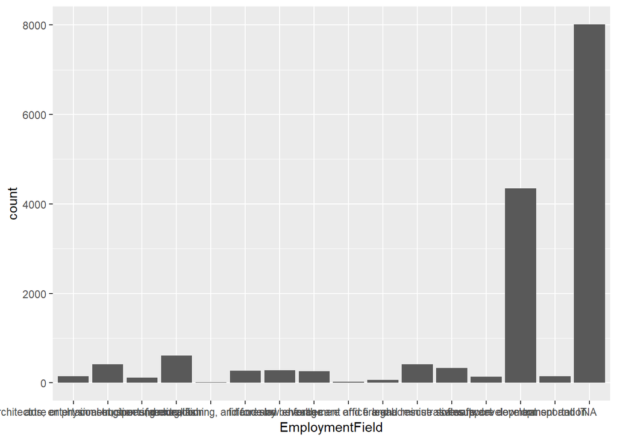

```r
df %>% ggplot(aes(EmploymentField)) + geom_bar()
```

## flip it and order bars

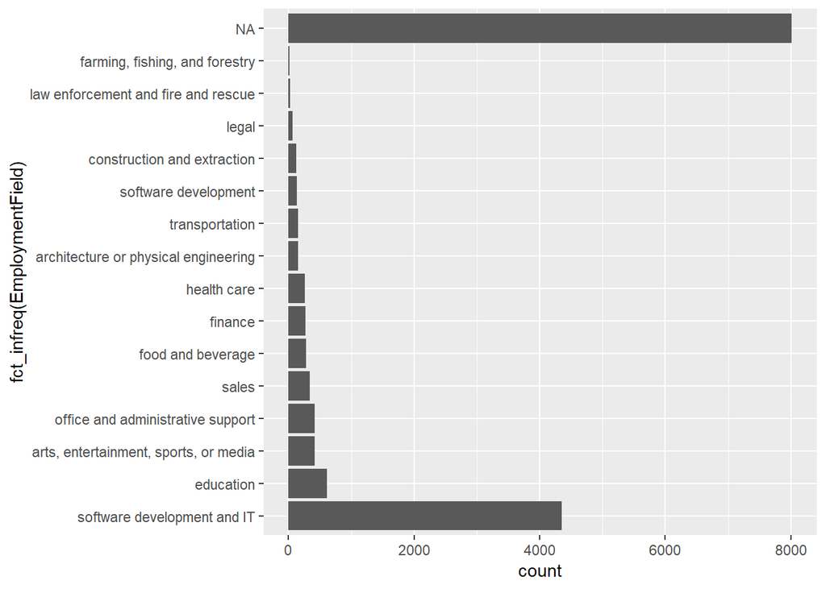

```r
df %>% ggplot(aes(fct_infreq(EmploymentField))) + #fct_infreq is an easy way to order factors using the forcats package
  geom_bar() +
  coord_flip()  # this flips the bars
```

## Get rid of NA

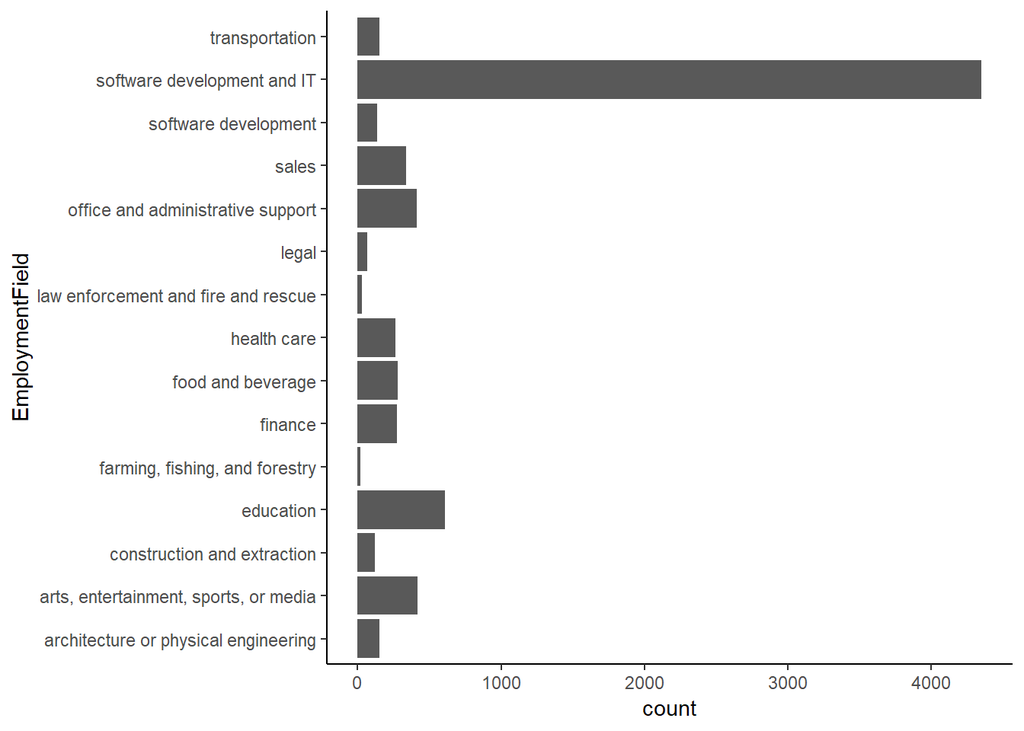

```r
df %>% filter(EmploymentField!="") %>%
  ggplot(aes(EmploymentField)) +
  geom_bar() +
  coord_flip() +
  theme_classic()
```

## Create a simple histogram

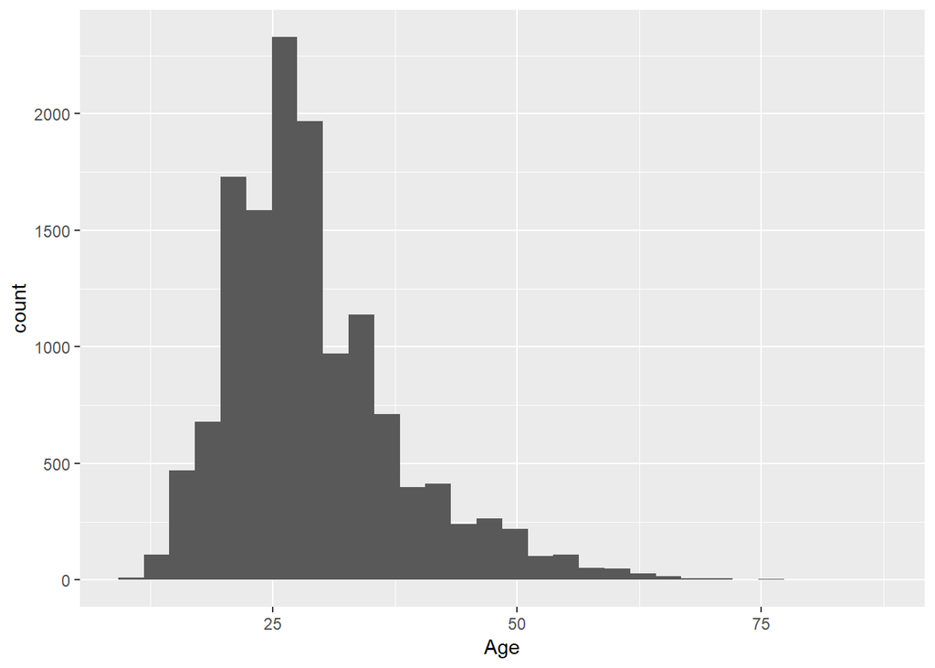

```r
df %>% ggplot(aes(x=Age)) +
  geom_histogram()
```

## make it look pretty

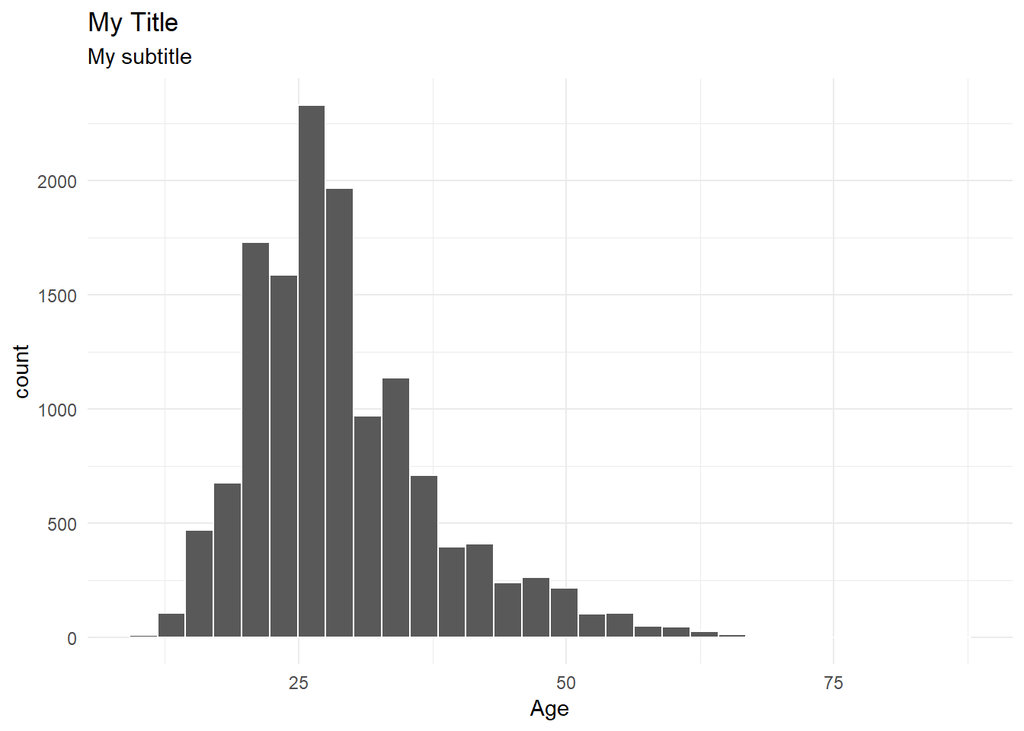

```r
df %>% ggplot(aes(x=Age)) +
  geom_histogram(color = "white") +
  theme_minimal() +
  labs(title = "My Title", subtitle = "My subtitle")
```

## try another theme

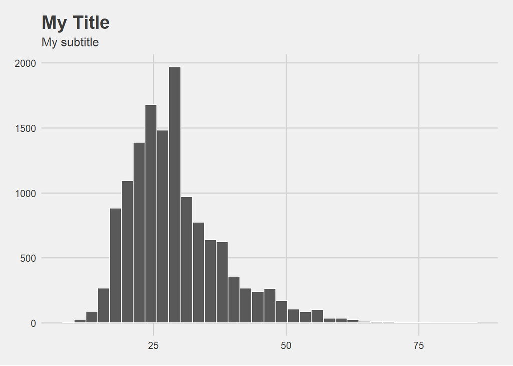

```r
df %>% ggplot(aes(x=Age)) +
  geom_histogram(color = "white", bins = 35) +
  theme_fivethirtyeight() +
  labs(title = "My Title", subtitle = "My subtitle")
```

## INSTRUCTIONS

1 Change the x variable with another numeric variable  
2 Change the theme & titles  
3 Change the number of bins

## Create a density plot instead of a histogram

Compare only males and females

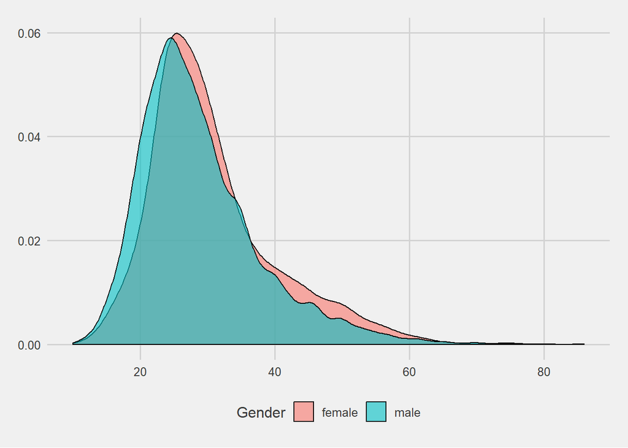

```r
df %>% filter(Gender == "female" | Gender == "male") %>%
  ggplot(aes(x=Age, fill = Gender)) +
  geom_density(alpha = .6) +
  theme_fivethirtyeight()
```

## Other examples of charts with the ggplot package

# Relationship between employment status and job preference

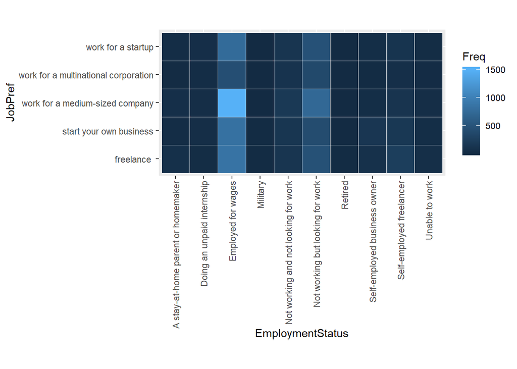

```r
df %>% flat_table(EmploymentStatus, JobPref) %>% data.frame() %>%
  ggplot(aes(EmploymentStatus, JobPref)) +
  geom_tile(aes(fill = Freq), colour = "white") +
  scale_fill_continuous() +
  coord_fixed(ratio = 1) +
  theme(axis.text.x=element_text(angle=90,hjust=1,vjust=0.5))
```

## Stacked bar chart

Comparing gender breakdown across ages

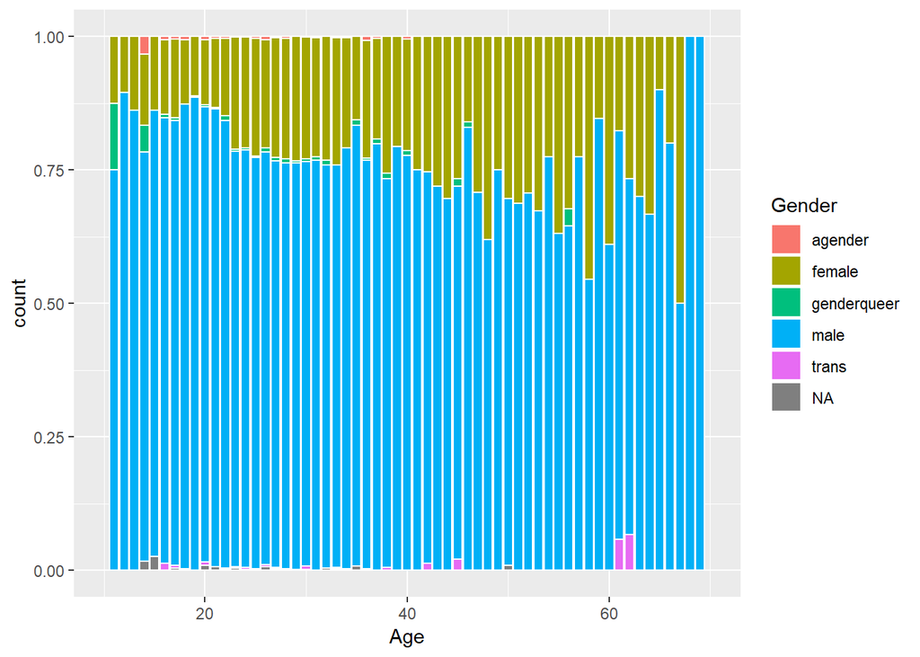

```r
df %>% select(Age, Gender) %>%
  group_by(Age, Gender) %>%
  summarise(count=n()) %>%
  ggplot(aes(Age,count,fill=Gender)) +
  geom_bar(stat='identity', position='fill', color='white') +
  xlim(c(10,70))
```